# Risk Factor Analysis

## Outcome Variable

**Outcome Variable:** ever_sstunted

## Predictor Variables

**Intervention Variable:** fage

**Adjustment Set:**

- arm
- W_mage
- meducyrs
- feducyrs
- W_mhtcm
- W_mwtkg
- W_mbmi
- W_fhtcm
- single
- brthmon
- delta_W_mage
- delta_meducyrs
- delta_feducyrs
- delta_W_mhtcm
- delta_W_mwtkg
- delta_W_mbmi
- delta_W_fhtcm
- delta_single
- delta_brthmon

## Stratifying Variables

The analysis was stratified on these variable(s):

- agecat
- studyid
- country

## Data Summary

| agecat | studyid | country | fage | ever_sstunted | n_cell | n |
| --- | --- | --- | --- | --- | --- | --- |
| 0-24 months | ki0047075b-MAL-ED | BANGLADESH | >=38 | 0 | 54 | 151 |
| 0-24 months | ki0047075b-MAL-ED | BANGLADESH | >=38 | 1 | 15 | 151 |
| 0-24 months | ki0047075b-MAL-ED | BANGLADESH | <32 | 0 | 21 | 151 |
| 0-24 months | ki0047075b-MAL-ED | BANGLADESH | <32 | 1 | 9 | 151 |
| 0-24 months | ki0047075b-MAL-ED | BANGLADESH | [32-38) | 0 | 41 | 151 |
| 0-24 months | ki0047075b-MAL-ED | BANGLADESH | [32-38) | 1 | 11 | 151 |
| 0-24 months | ki0047075b-MAL-ED | BRAZIL | >=38 | 0 | 27 | 79 |
| 0-24 months | ki0047075b-MAL-ED | BRAZIL | >=38 | 1 | 3 | 79 |
| 0-24 months | ki0047075b-MAL-ED | BRAZIL | <32 | 0 | 17 | 79 |
| 0-24 months | ki0047075b-MAL-ED | BRAZIL | <32 | 1 | 1 | 79 |
| 0-24 months | ki0047075b-MAL-ED | BRAZIL | [32-38) | 0 | 29 | 79 |
| 0-24 months | ki0047075b-MAL-ED | BRAZIL | [32-38) | 1 | 2 | 79 |
| 0-24 months | ki0047075b-MAL-ED | INDIA | >=38 | 0 | 30 | 161 |
| 0-24 months | ki0047075b-MAL-ED | INDIA | >=38 | 1 | 6 | 161 |
| 0-24 months | ki0047075b-MAL-ED | INDIA | <32 | 0 | 39 | 161 |
| 0-24 months | ki0047075b-MAL-ED | INDIA | <32 | 1 | 14 | 161 |
| 0-24 months | ki0047075b-MAL-ED | INDIA | [32-38) | 0 | 59 | 161 |
| 0-24 months | ki0047075b-MAL-ED | INDIA | [32-38) | 1 | 13 | 161 |
| 0-24 months | ki0047075b-MAL-ED | NEPAL | >=38 | 0 | 16 | 79 |
| 0-24 months | ki0047075b-MAL-ED | NEPAL | >=38 | 1 | 1 | 79 |
| 0-24 months | ki0047075b-MAL-ED | NEPAL | <32 | 0 | 13 | 79 |
| 0-24 months | ki0047075b-MAL-ED | NEPAL | <32 | 1 | 2 | 79 |
| 0-24 months | ki0047075b-MAL-ED | NEPAL | [32-38) | 0 | 41 | 79 |
| 0-24 months | ki0047075b-MAL-ED | NEPAL | [32-38) | 1 | 6 | 79 |
| 0-24 months | ki0047075b-MAL-ED | PERU | >=38 | 0 | 24 | 85 |
| 0-24 months | ki0047075b-MAL-ED | PERU | >=38 | 1 | 3 | 85 |
| 0-24 months | ki0047075b-MAL-ED | PERU | <32 | 0 | 21 | 85 |
| 0-24 months | ki0047075b-MAL-ED | PERU | <32 | 1 | 8 | 85 |
| 0-24 months | ki0047075b-MAL-ED | PERU | [32-38) | 0 | 18 | 85 |
| 0-24 months | ki0047075b-MAL-ED | PERU | [32-38) | 1 | 11 | 85 |

[output cut: 126 more lines]

The following strata were considered:

- agecat: 0-24 months, studyid: ki0047075b-MAL-ED, country: BANGLADESH
- agecat: 0-24 months, studyid: ki0047075b-MAL-ED, country: BRAZIL
- agecat: 0-24 months, studyid: ki0047075b-MAL-ED, country: INDIA
- agecat: 0-24 months, studyid: ki0047075b-MAL-ED, country: NEPAL
- agecat: 0-24 months, studyid: ki0047075b-MAL-ED, country: PERU
- agecat: 0-24 months, studyid: ki0047075b-MAL-ED, country: SOUTH AFRICA
- agecat: 0-24 months, studyid: ki0047075b-MAL-ED, country: TANZANIA, UNITED REPUBLIC OF
- agecat: 0-24 months, studyid: ki1000304b-SAS-CompFeed, country: INDIA
- agecat: 0-24 months, studyid: ki1000304b-SAS-FoodSuppl, country: INDIA
- agecat: 0-24 months, studyid: ki1119695-PROBIT, country: BELARUS
- agecat: 0-24 months, studyid: ki1135781-COHORTS, country: GUATEMALA
- agecat: 0-24 months, studyid: ki1135781-COHORTS, country: PHILIPPINES
- agecat: 0-24 months, studyid: ki1148112-LCNI-5, country: MALAWI
- agecat: 0-6 months, studyid: ki0047075b-MAL-ED, country: BANGLADESH
- agecat: 0-6 months, studyid: ki0047075b-MAL-ED, country: BRAZIL
- agecat: 0-6 months, studyid: ki0047075b-MAL-ED, country: INDIA
- agecat: 0-6 months, studyid: ki0047075b-MAL-ED, country: NEPAL
- agecat: 0-6 months, studyid: ki0047075b-MAL-ED, country: PERU
- agecat: 0-6 months, studyid: ki0047075b-MAL-ED, country: SOUTH AFRICA
- agecat: 0-6 months, studyid: ki0047075b-MAL-ED, country: TANZANIA, UNITED REPUBLIC OF
- agecat: 0-6 months, studyid: ki1000304b-SAS-CompFeed, country: INDIA
- agecat: 0-6 months, studyid: ki1000304b-SAS-FoodSuppl, country: INDIA
- agecat: 0-6 months, studyid: ki1119695-PROBIT, country: BELARUS
- agecat: 0-6 months, studyid: ki1135781-COHORTS, country: GUATEMALA
- agecat: 0-6 months, studyid: ki1135781-COHORTS, country: PHILIPPINES
- agecat: 0-6 months, studyid: ki1148112-LCNI-5, country: MALAWI

### Dropped Strata

Some strata were dropped due to rare outcomes:

- agecat: 0-24 months, studyid: ki0047075b-MAL-ED, country: BRAZIL
- agecat: 0-24 months, studyid: ki0047075b-MAL-ED, country: NEPAL
- agecat: 0-24 months, studyid: ki0047075b-MAL-ED, country: PERU
- agecat: 0-24 months, studyid: ki0047075b-MAL-ED, country: SOUTH AFRICA
- agecat: 0-24 months, studyid: ki0047075b-MAL-ED, country: TANZANIA, UNITED REPUBLIC OF
- agecat: 0-24 months, studyid: ki1148112-LCNI-5, country: MALAWI
- agecat: 0-6 months, studyid: ki0047075b-MAL-ED, country: BANGLADESH
- agecat: 0-6 months, studyid: ki0047075b-MAL-ED, country: BRAZIL
- agecat: 0-6 months, studyid: ki0047075b-MAL-ED, country: INDIA
- agecat: 0-6 months, studyid: ki0047075b-MAL-ED, country: NEPAL
- agecat: 0-6 months, studyid: ki0047075b-MAL-ED, country: PERU
- agecat: 0-6 months, studyid: ki0047075b-MAL-ED, country: SOUTH AFRICA
- agecat: 0-6 months, studyid: ki0047075b-MAL-ED, country: TANZANIA, UNITED REPUBLIC OF
- agecat: 0-6 months, studyid: ki1148112-LCNI-5, country: MALAWI

## Methods Detail

We’re interested in the causal parameters $E[Y_a]$ for all values of $a \in \mathcal{A}$. These parameters represent the mean outcome if, possibly contrary to fact, we intervened to set all units to have $A=a$. Under the randomization and positivity assumptions, these are identified by the statistical parameters $\psi_a=E_W[E_{Y|A,W}(Y|A=a,W)]$. In addition, we’re interested in the mean of $Y$, $E[Y]$ under no intervention (the observed mean). We will estimate these parameters by using SuperLearner to fit the relevant likelihood factors – $E_{Y|A,W}(Y|A=a,W)$ and $p(A=a|W)$, and then updating our likelihood fit using a joint TMLE.

For unadjusted analyses ($W=\{\}$), initial likelihoods were estimated using Lrnr_glm to estimate the simple $E(Y|A)$ and Lrnr_mean to estimate $p(A)$. For adjusted analyses, a small library containing Lrnr_glmnet, Lrnr_xgboost, and Lrnr_mean was used.

Having estimated these parameters, we will then use the delta method to estimate relative risks and attributable risks relative to a prespecified baseline level of $A$.

# Results Detail

## Results Plots

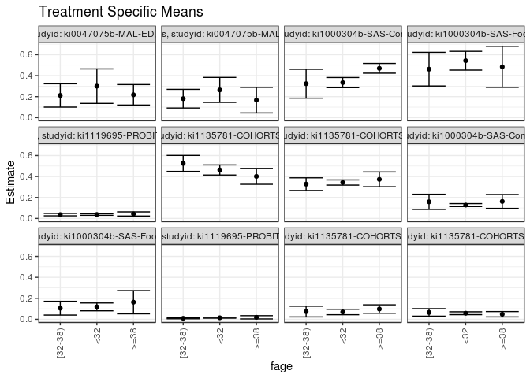

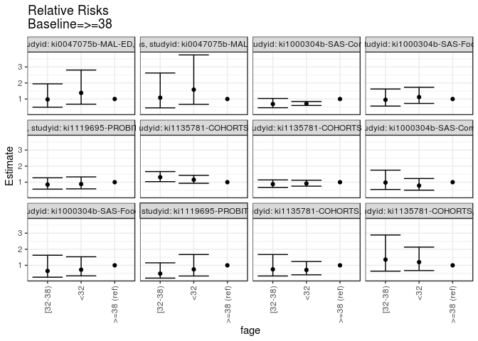

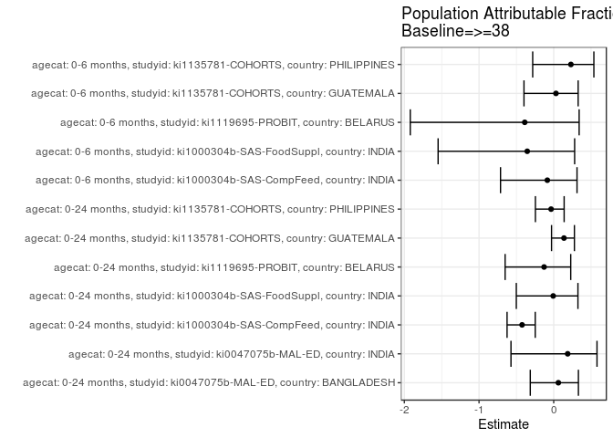

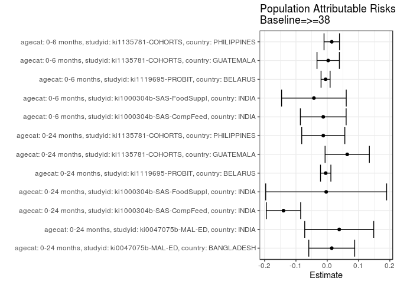

## Results Table

### Parameter: TSM

| agecat | studyid | country | intervention_level | baseline_level | estimate | ci_lower | ci_upper |
| --- | --- | --- | --- | --- | --- | --- | --- |
| 0-24 months | ki0047075b-MAL-ED | BANGLADESH | >=38 | NA | 0.2173913 | 0.1197441 | 0.3150385 |
| 0-24 months | ki0047075b-MAL-ED | BANGLADESH | <32 | NA | 0.3000000 | 0.1354719 | 0.4645281 |
| 0-24 months | ki0047075b-MAL-ED | BANGLADESH | [32-38) | NA | 0.2115385 | 0.1001669 | 0.3229100 |
| 0-24 months | ki0047075b-MAL-ED | INDIA | >=38 | NA | 0.1666667 | 0.0445476 | 0.2887858 |
| 0-24 months | ki0047075b-MAL-ED | INDIA | <32 | NA | 0.2641509 | 0.1450861 | 0.3832158 |
| 0-24 months | ki0047075b-MAL-ED | INDIA | [32-38) | NA | 0.1805556 | 0.0914305 | 0.2696806 |
| 0-24 months | ki1000304b-SAS-CompFeed | INDIA | >=38 | NA | 0.4698957 | 0.4234464 | 0.5163450 |
| 0-24 months | ki1000304b-SAS-CompFeed | INDIA | <32 | NA | 0.3337477 | 0.2854355 | 0.3820598 |
| 0-24 months | ki1000304b-SAS-CompFeed | INDIA | [32-38) | NA | 0.3231768 | 0.1854237 | 0.4609299 |
| 0-24 months | ki1000304b-SAS-FoodSuppl | INDIA | >=38 | NA | 0.4842677 | 0.2888063 | 0.6797292 |
| 0-24 months | ki1000304b-SAS-FoodSuppl | INDIA | <32 | NA | 0.5424109 | 0.4530298 | 0.6317920 |
| 0-24 months | ki1000304b-SAS-FoodSuppl | INDIA | [32-38) | NA | 0.4618462 | 0.3013510 | 0.6223414 |
| 0-24 months | ki1119695-PROBIT | BELARUS | >=38 | NA | 0.0431439 | 0.0233077 | 0.0629801 |
| 0-24 months | ki1119695-PROBIT | BELARUS | <32 | NA | 0.0380087 | 0.0302317 | 0.0457857 |
| 0-24 months | ki1119695-PROBIT | BELARUS | [32-38) | NA | 0.0366118 | 0.0250187 | 0.0482050 |
| 0-24 months | ki1135781-COHORTS | GUATEMALA | >=38 | NA | 0.4011672 | 0.3254441 | 0.4768904 |
| 0-24 months | ki1135781-COHORTS | GUATEMALA | <32 | NA | 0.4622723 | 0.4140608 | 0.5104837 |
| 0-24 months | ki1135781-COHORTS | GUATEMALA | [32-38) | NA | 0.5249542 | 0.4486745 | 0.6012339 |
| 0-24 months | ki1135781-COHORTS | PHILIPPINES | >=38 | NA | 0.3728630 | 0.3024211 | 0.4433049 |
| 0-24 months | ki1135781-COHORTS | PHILIPPINES | <32 | NA | 0.3425315 | 0.3177273 | 0.3673358 |
| 0-24 months | ki1135781-COHORTS | PHILIPPINES | [32-38) | NA | 0.3270276 | 0.2664316 | 0.3876235 |
| 0-6 months | ki1000304b-SAS-CompFeed | INDIA | >=38 | NA | 0.1620636 | 0.0955660 | 0.2285612 |
| 0-6 months | ki1000304b-SAS-CompFeed | INDIA | <32 | NA | 0.1272574 | 0.1131811 | 0.1413337 |
| 0-6 months | ki1000304b-SAS-CompFeed | INDIA | [32-38) | NA | 0.1582715 | 0.0855577 | 0.2309852 |
| 0-6 months | ki1000304b-SAS-FoodSuppl | INDIA | >=38 | NA | 0.1627907 | 0.0523146 | 0.2732668 |
| 0-6 months | ki1000304b-SAS-FoodSuppl | INDIA | <32 | NA | 0.1180556 | 0.0807444 | 0.1553667 |
| 0-6 months | ki1000304b-SAS-FoodSuppl | INDIA | [32-38) | NA | 0.1058824 | 0.0403931 | 0.1713717 |
| 0-6 months | ki1119695-PROBIT | BELARUS | >=38 | NA | 0.0191052 | 0.0035622 | 0.0346481 |
| 0-6 months | ki1119695-PROBIT | BELARUS | <32 | NA | 0.0143167 | 0.0105980 | 0.0180354 |
| 0-6 months | ki1119695-PROBIT | BELARUS | [32-38) | NA | 0.0092686 | 0.0050860 | 0.0134512 |
| 0-6 months | ki1135781-COHORTS | GUATEMALA | >=38 | NA | 0.0977308 | 0.0578612 | 0.1376003 |
| 0-6 months | ki1135781-COHORTS | GUATEMALA | <32 | NA | 0.0695615 | 0.0436779 | 0.0954452 |
| 0-6 months | ki1135781-COHORTS | GUATEMALA | [32-38) | NA | 0.0734134 | 0.0228278 | 0.1239990 |
| 0-6 months | ki1135781-COHORTS | PHILIPPINES | >=38 | NA | 0.0482570 | 0.0228067 | 0.0737074 |
| 0-6 months | ki1135781-COHORTS | PHILIPPINES | <32 | NA | 0.0578789 | 0.0443959 | 0.0713620 |
| 0-6 months | ki1135781-COHORTS | PHILIPPINES | [32-38) | NA | 0.0654613 | 0.0299361 | 0.1009864 |

### Parameter: E(Y)

| agecat | studyid | country | intervention_level | baseline_level | estimate | ci_lower | ci_upper |
| --- | --- | --- | --- | --- | --- | --- | --- |
| 0-24 months | ki0047075b-MAL-ED | BANGLADESH | NA | NA | 0.2317881 | 0.1642594 | 0.2993168 |
| 0-24 months | ki0047075b-MAL-ED | INDIA | NA | NA | 0.2049689 | 0.1424194 | 0.2675185 |
| 0-24 months | ki1000304b-SAS-CompFeed | INDIA | NA | NA | 0.3300654 | 0.3020915 | 0.3580392 |
| 0-24 months | ki1000304b-SAS-FoodSuppl | INDIA | NA | NA | 0.4808612 | 0.4329065 | 0.5288160 |
| 0-24 months | ki1119695-PROBIT | BELARUS | NA | NA | 0.0382134 | 0.0300125 | 0.0464143 |
| 0-24 months | ki1135781-COHORTS | GUATEMALA | NA | NA | 0.4650269 | 0.4379137 | 0.4921401 |
| 0-24 months | ki1135781-COHORTS | PHILIPPINES | NA | NA | 0.3602169 | 0.3428934 | 0.3775404 |
| 0-6 months | ki1000304b-SAS-CompFeed | INDIA | NA | NA | 0.1493124 | 0.1303783 | 0.1682465 |
| 0-6 months | ki1000304b-SAS-FoodSuppl | INDIA | NA | NA | 0.1201923 | 0.0889059 | 0.1514788 |
| 0-6 months | ki1119695-PROBIT | BELARUS | NA | NA | 0.0137651 | 0.0103766 | 0.0171537 |
| 0-6 months | ki1135781-COHORTS | GUATEMALA | NA | NA | 0.1007605 | 0.0825622 | 0.1189587 |
| 0-6 months | ki1135781-COHORTS | PHILIPPINES | NA | NA | 0.0626906 | 0.0539432 | 0.0714380 |

### Parameter: RR

| agecat | studyid | country | intervention_level | baseline_level | estimate | ci_lower | ci_upper |
| --- | --- | --- | --- | --- | --- | --- | --- |
| 0-24 months | ki0047075b-MAL-ED | BANGLADESH | >=38 | >=38 | 1.0000000 | 1.0000000 | 1.0000000 |
| 0-24 months | ki0047075b-MAL-ED | BANGLADESH | <32 | >=38 | 1.3800000 | 0.6792191 | 2.8038080 |
| 0-24 months | ki0047075b-MAL-ED | BANGLADESH | [32-38) | >=38 | 0.9730769 | 0.4870684 | 1.9440364 |
| 0-24 months | ki0047075b-MAL-ED | INDIA | >=38 | >=38 | 1.0000000 | 1.0000000 | 1.0000000 |
| 0-24 months | ki0047075b-MAL-ED | INDIA | <32 | >=38 | 1.5849057 | 0.6704997 | 3.7463493 |
| 0-24 months | ki0047075b-MAL-ED | INDIA | [32-38) | >=38 | 1.0833333 | 0.4477896 | 2.6208985 |
| 0-24 months | ki1000304b-SAS-CompFeed | INDIA | >=38 | >=38 | 1.0000000 | 1.0000000 | 1.0000000 |
| 0-24 months | ki1000304b-SAS-CompFeed | INDIA | <32 | >=38 | 0.7102590 | 0.5987986 | 0.8424667 |
| 0-24 months | ki1000304b-SAS-CompFeed | INDIA | [32-38) | >=38 | 0.6877629 | 0.4571461 | 1.0347192 |
| 0-24 months | ki1000304b-SAS-FoodSuppl | INDIA | >=38 | >=38 | 1.0000000 | 1.0000000 | 1.0000000 |
| 0-24 months | ki1000304b-SAS-FoodSuppl | INDIA | <32 | >=38 | 1.1200641 | 0.7251508 | 1.7300450 |
| 0-24 months | ki1000304b-SAS-FoodSuppl | INDIA | [32-38) | >=38 | 0.9537001 | 0.5598922 | 1.6244984 |
| 0-24 months | ki1119695-PROBIT | BELARUS | >=38 | >=38 | 1.0000000 | 1.0000000 | 1.0000000 |
| 0-24 months | ki1119695-PROBIT | BELARUS | <32 | >=38 | 0.8809762 | 0.5845439 | 1.3277345 |
| 0-24 months | ki1119695-PROBIT | BELARUS | [32-38) | >=38 | 0.8485989 | 0.5669173 | 1.2702385 |
| 0-24 months | ki1135781-COHORTS | GUATEMALA | >=38 | >=38 | 1.0000000 | 1.0000000 | 1.0000000 |
| 0-24 months | ki1135781-COHORTS | GUATEMALA | <32 | >=38 | 1.1523180 | 0.9298748 | 1.4279739 |
| 0-24 months | ki1135781-COHORTS | GUATEMALA | [32-38) | >=38 | 1.3085669 | 1.0324791 | 1.6584814 |
| 0-24 months | ki1135781-COHORTS | PHILIPPINES | >=38 | >=38 | 1.0000000 | 1.0000000 | 1.0000000 |
| 0-24 months | ki1135781-COHORTS | PHILIPPINES | <32 | >=38 | 0.9186525 | 0.7508534 | 1.1239510 |
| 0-24 months | ki1135781-COHORTS | PHILIPPINES | [32-38) | >=38 | 0.8770716 | 0.6735118 | 1.1421547 |
| 0-6 months | ki1000304b-SAS-CompFeed | INDIA | >=38 | >=38 | 1.0000000 | 1.0000000 | 1.0000000 |
| 0-6 months | ki1000304b-SAS-CompFeed | INDIA | <32 | >=38 | 0.7852314 | 0.5024341 | 1.2272022 |
| 0-6 months | ki1000304b-SAS-CompFeed | INDIA | [32-38) | >=38 | 0.9766013 | 0.5454635 | 1.7485134 |
| 0-6 months | ki1000304b-SAS-FoodSuppl | INDIA | >=38 | >=38 | 1.0000000 | 1.0000000 | 1.0000000 |
| 0-6 months | ki1000304b-SAS-FoodSuppl | INDIA | <32 | >=38 | 0.7251984 | 0.3430315 | 1.5331325 |
| 0-6 months | ki1000304b-SAS-FoodSuppl | INDIA | [32-38) | >=38 | 0.6504202 | 0.2596698 | 1.6291705 |
| 0-6 months | ki1119695-PROBIT | BELARUS | >=38 | >=38 | 1.0000000 | 1.0000000 | 1.0000000 |
| 0-6 months | ki1119695-PROBIT | BELARUS | <32 | >=38 | 0.7493614 | 0.3357709 | 1.6723977 |
| 0-6 months | ki1119695-PROBIT | BELARUS | [32-38) | >=38 | 0.4851377 | 0.2039062 | 1.1542493 |
| 0-6 months | ki1135781-COHORTS | GUATEMALA | >=38 | >=38 | 1.0000000 | 1.0000000 | 1.0000000 |
| 0-6 months | ki1135781-COHORTS | GUATEMALA | <32 | >=38 | 0.7117670 | 0.4094858 | 1.2371914 |
| 0-6 months | ki1135781-COHORTS | GUATEMALA | [32-38) | >=38 | 0.7511802 | 0.3368149 | 1.6753169 |
| 0-6 months | ki1135781-COHORTS | PHILIPPINES | >=38 | >=38 | 1.0000000 | 1.0000000 | 1.0000000 |
| 0-6 months | ki1135781-COHORTS | PHILIPPINES | <32 | >=38 | 1.1993891 | 0.6743579 | 2.1331911 |
| 0-6 months | ki1135781-COHORTS | PHILIPPINES | [32-38) | >=38 | 1.3565129 | 0.6370472 | 2.8885257 |

### Parameter: PAR

| agecat | studyid | country | intervention_level | baseline_level | estimate | ci_lower | ci_upper |
| --- | --- | --- | --- | --- | --- | --- | --- |
| 0-24 months | ki0047075b-MAL-ED | BANGLADESH | >=38 | NA | 0.0143968 | -0.0589587 | 0.0877522 |
| 0-24 months | ki0047075b-MAL-ED | INDIA | >=38 | NA | 0.0383023 | -0.0719534 | 0.1485580 |
| 0-24 months | ki1000304b-SAS-CompFeed | INDIA | >=38 | NA | -0.1398303 | -0.1947511 | -0.0849096 |
| 0-24 months | ki1000304b-SAS-FoodSuppl | INDIA | >=38 | NA | -0.0034065 | -0.1966198 | 0.1898068 |
| 0-24 months | ki1119695-PROBIT | BELARUS | >=38 | NA | -0.0049304 | -0.0214890 | 0.0116281 |
| 0-24 months | ki1135781-COHORTS | GUATEMALA | >=38 | NA | 0.0638597 | -0.0069029 | 0.1346222 |
| 0-24 months | ki1135781-COHORTS | PHILIPPINES | >=38 | NA | -0.0126461 | -0.0815148 | 0.0562226 |
| 0-6 months | ki1000304b-SAS-CompFeed | INDIA | >=38 | NA | -0.0127512 | -0.0858650 | 0.0603626 |
| 0-6 months | ki1000304b-SAS-FoodSuppl | INDIA | >=38 | NA | -0.0425984 | -0.1458489 | 0.0606521 |
| 0-6 months | ki1119695-PROBIT | BELARUS | >=38 | NA | -0.0053400 | -0.0197842 | 0.0091041 |
| 0-6 months | ki1135781-COHORTS | GUATEMALA | >=38 | NA | 0.0030297 | -0.0327192 | 0.0387786 |
| 0-6 months | ki1135781-COHORTS | PHILIPPINES | >=38 | NA | 0.0144336 | -0.0102604 | 0.0391276 |

### Parameter: PAF

| agecat | studyid | country | intervention_level | baseline_level | estimate | ci_lower | ci_upper |
| --- | --- | --- | --- | --- | --- | --- | --- |
| 0-24 months | ki0047075b-MAL-ED | BANGLADESH | >=38 | NA | 0.0621118 | -0.3139935 | 0.3305642 |
| 0-24 months | ki0047075b-MAL-ED | INDIA | >=38 | NA | 0.1868687 | -0.5722522 | 0.5794679 |
| 0-24 months | ki1000304b-SAS-CompFeed | INDIA | >=38 | NA | -0.4236444 | -0.6246661 | -0.2474953 |
| 0-24 months | ki1000304b-SAS-FoodSuppl | INDIA | >=38 | NA | -0.0070842 | -0.5009438 | 0.3242795 |
| 0-24 months | ki1119695-PROBIT | BELARUS | >=38 | NA | -0.1290237 | -0.6507282 | 0.2277986 |
| 0-24 months | ki1135781-COHORTS | GUATEMALA | >=38 | NA | 0.1373247 | -0.0293199 | 0.2769898 |
| 0-24 months | ki1135781-COHORTS | PHILIPPINES | >=38 | NA | -0.0351070 | -0.2451672 | 0.1395159 |
| 0-6 months | ki1000304b-SAS-CompFeed | INDIA | >=38 | NA | -0.0853994 | -0.7122306 | 0.3119550 |
| 0-6 months | ki1000304b-SAS-FoodSuppl | INDIA | >=38 | NA | -0.3544186 | -1.5480213 | 0.2800493 |
| 0-6 months | ki1119695-PROBIT | BELARUS | >=38 | NA | -0.3879396 | -1.9206309 | 0.3404246 |
| 0-6 months | ki1135781-COHORTS | GUATEMALA | >=38 | NA | 0.0300682 | -0.3982459 | 0.3271801 |
| 0-6 months | ki1135781-COHORTS | PHILIPPINES | >=38 | NA | 0.2302354 | -0.2814826 | 0.5376156 |